# Bayesian Hierarchical Modeling with RStan

[Dorsa M. Arezooji](https://Dorsa-Arezooji.github.io)

## 1. loading the dataset & create the dataframe

```r
setwd("~/Desktop/MSc Project/rstan/pigs")
library(rstan)
library(gsubfn)
library(pracma)
library(scales)
```

```r
pigs <- read.csv("~/Desktop/MSc Project/rstan/pigs/pigs.csv")
df = data.frame(pigs)
summary(df)
```

```
 survivors..y.      number..n.       dose..x.
 Min.   : 0.000   Min.   :10.00   Min.   :0.730
 1st Qu.: 1.000   1st Qu.:19.00   1st Qu.:1.185
 Median : 4.000   Median :20.00   Median :1.300
 Mean   : 6.183   Mean   :24.49   Mean   :1.276
 3rd Qu.: 7.500   3rd Qu.:22.50   3rd Qu.:1.380
 Max.   :45.000   Max.   :52.00   Max.   :1.890
```

```r
print(df)
```

| survivors..y. | number..n. | dose..x. |
| --- | --- | --- |
| 0 | 20 | 0.73 |
| 0 | 19 | 0.73 |
| 0 | 20 | 0.74 |
| 0 | 19 | 0.74 |
| 0 | 17 | 0.74 |
| 0 | 20 | 0.75 |
| 0 | 20 | 0.75 |
| 0 | 18 | 0.75 |
| 0 | 20 | 0.76 |
| 0 | 19 | 0.76 |

[output cut: 61 more lines]

## 2. Creating the Data List

`E` : number of experiments  
`x` : dosage vector  
`N` : total number of pigs  
`n` : number of cured pigs

```r
d = list(
  E = nrow(df),
  x = df[[3]],
  N = df[[2]],
  n = df[[1]]
)
sprintf('the data list has %s enteries' , d[1])
```

```
[1] "the data list has 71 enteries"
```

## 3. Creating the Stan Models

in order to avoid having to write the stan codes for all 21 models, run the cell bellow and replace `dist_a` and `dist_b` with the proper distributions for alpha and beta

```r
m = '
data {
  int<lower=1> E;
  vector[E] x;
  int<lower=1> N[E];
  int<lower=0> n [E];
}

parameters {
  real alpha;
  real beta;
}

model {
  alpha ~ dist_a;
  beta ~ dist_b;
  n ~ binomial_logit(N, alpha + beta * x);
}
'
```

## 4. Automating the Results with Functions

create a `results` dataframe to store the results and automatically populate it by invoking the `get_results` function

```r
# initialize the results dataframe
results = data.frame('Model' = 1:21,
                     'PriorType' = c(rep('beta', 4), rep('logistic', 3), rep('normal', 5), rep('uniform', 8), rep('weibull', 1)),
                     'RunTime' = rep(0,21),
                     'alpha_mean' = rep(0,21),
                     'alpha_sd' = rep(0,21),
                     'beta_mean' = rep(0,21),
                     'beta_sd' = rep(0,21),
                     'n_eff_alpha' = rep(0,21),
                     'Rhat_alpha' = rep(0,21),
                     'n_eff_beta' = rep(0,21),
                     'Rhat_beta' = rep(0,21),
                     'lp' = rep(0,21))


# a function to insert the results from each model into the results df

get_results = function(i, fit_i){
  r = summary(fit_i, pars = c('alpha', 'beta', 'lp__'))$summary
  results['RunTime'][[1]][i] = sum(get_elapsed_time(fit_i))
  results['alpha_mean'][[1]][i] = r['alpha', 'mean']
  results['beta_mean'][[1]][i] = r['beta', 'mean']
  results['alpha_sd'][[1]][i] = r['alpha', 'sd']
  results['beta_sd'][[1]][i] = r['beta', 'sd']
  results['lp'][[1]][i] = r['lp__', 'mean']
  results['n_eff_alpha'][[1]][i] = r['alpha', 'n_eff']
  results['Rhat_alpha'][[1]][i] = r['alpha', 'Rhat']
  results['n_eff_beta'][[1]][i] = r['beta', 'n_eff']
  results['Rhat_beta'][[1]][i] = r['beta', 'Rhat']
  return(results)
}

# a function to plot the posterior densities of a model

prior_posterior_vis = function(fit, type, p1, p2, a="alpha", b="beta", m='default', l='default'){
  if(toString(m) == 'default'){
    m = paste('a, b', '~', type, '(', p1, ',', p2, ')')
  }
  if(toString(l) == 'default'){
    l = c(expression(alpha['prior'], beta['prior'], alpha['posterior'], beta['posterior']))
  }
  a_den = density(fit@sim[["samples"]][[1]][[a]])
  b_den = density(fit@sim[["samples"]][[1]][[b]])
  x0 = -25
  x1 = 30
  x_range = c(-20, 25)
  y_range = c(0, 0.8)
  plot(a_den, xlim=x_range, ylim=y_range, col="purple", lwd = 3, xlab='', ylab='Probability Density', main=m, cex.main=1, font.main = 1)
  xlabel <- seq(-20, 25, by = 5)
  axis(1, at = xlabel, las = 1)
  par(new=TRUE)
  plot(b_den, xlim=x_range, ylim=y_range, col="violet", lwd = 3, xlab='', ylab='Probability Density', main='')
  par(new=TRUE)
  abline(xlim=x_range, ylim=y_range, v=-14.03, col=alpha("purple", 0.5), lwd=2)
  par(new=TRUE)
  abline(xlim=x_range, ylim=y_range, v=9.39, col=alpha("violet", 0.5), lwd=2)
  if (type == 'logistic'){
    curve((0.25/p2)*(sech(0.5*(x-p1)/p2)^2), x0, x1, ylim=y_range, add=TRUE, col=alpha("pink", 0.6), lwd = 3)
  }
  if (type == 'normal'){
    curve(exp(-0.5*((x-p1)/p2)^2)/(p2*sqrt(2*pi)), x0, x1, ylim=y_range, add=TRUE, col=alpha("pink", 0.6), lwd = 3)
  }
    if (type == 'uniform'){
    curve((x^0)/(p2-p1), x0, x1, ylim=y_range, add=TRUE, col=alpha("pink", 0.6), lwd = 3)
  }
  legend("bottomright", legend = l, col = c("pink", "pink", "purple", "violet"), pch = c("____ "), bty = "n", pt.cex = 3, cex = 1, text.col = "black", horiz = F , inset = c(0.01, 0.1))
}

# a function to implement different prior distributions

priorize = function(prior_a, prior_b){
  model_code = gsub('dist_a', prior_a, gsub('dist_b', prior_b, m))
  return(model_code)
}
```

## 5. Running the Stan Files

```r
m0 = '
data {
  int<lower=1> E; // number of experiments
  vector[E] x; // dosage vector
  int<lower=1> N[E]; // total number of pigs
  int<lower=0> n[E]; // number of cured pigs
}

parameters {
  real alpha;
  real beta;
}

model {
  n ~ binomial_logit(N, alpha + beta * x);
}
'
```

### 5.1. Beta Priors

Cab’t be used since the beta distribution in=s defined in range [0,1] **running the cells below will cause the simulation to hang**

```r
m1 = priorize('beta(0.5, 0.5)', 'beta(-100, 100)')
s1= stan(model_code = m1, data = d, chains = 4, iter = 3750, algorithm = 'HMC', refresh=0)
results = get_results(1, s1)
```

```r
m2 = priorize('beta(0.5, 0.5)', 'beta(-20, 20)')
s2 = stan(model_code = m2, data = d, chains = 4, iter = 3800, algorithm = 'HMC', refresh=0)
results = get_results(2, s2)
```

```r
m3 = priorize('beta(1, 1)', 'beta(-20, 20)')
s3 = stan(model_code = m3, data = d, chains = 4, iter = 3800, algorithm = 'HMC', refresh=0)
results = get_results(3, s3)
```

```r
m4 = priorize('beta(100, 100)', 'beta(-20, 20)')
s4 = stan(model_code = m4, data = d, chains = 4, iter = 3800, algorithm = 'HMC', refresh=0)
results = get_results(4, s4)
```

### 5.2. Logistic Priors

```r
m5 = priorize('logistic(0, 1)', 'logistic(0, 1)')
s5 = stan(model_code = m5, data = d, chains = 4, iter = 3800, algorithm = 'HMC', refresh=0)
results = get_results(5, s5)
```

```r
m6 = gsub('dist_a', 'logistic(0, 10)', gsub('dist_b', 'logistic(0, 10)', m))
s6 = stan(model_code = m6, data = d, chains = 4, iter = 3800, algorithm = 'HMC', refresh=0)
results = get_results(6, s6)
```

```r
m7 = gsub('dist_a', 'logistic(10, 10)', gsub('dist_b', 'logistic(10, 10)', m))
s7 = stan(model_code = m7, data = d, chains = 4, iter = 3800, algorithm = 'HMC', refresh=0)
results = get_results(7, s7)
```

### 5.3. Normal Priors

```r
m8 = gsub('dist_a', 'normal(0, 20)', gsub('dist_b', 'normal(0, 30)', m))
s8 = stan(model_code = m8, data = d, chains = 4, iter = 4000, algorithm = 'HMC', refresh=0)
results = get_results(8, s8)
```

```r
m9 = gsub('dist_a', 'normal(0, 1)', gsub('dist_b', 'normal(0, 1)', m))
s9 = stan(model_code = m9, data = d, chains = 4, iter = 4200, algorithm ='HMC', refresh=0)
results = get_results(9, s9)
```

```r
m10 = gsub('dist_a', 'normal(0, 100)', gsub('dist_b', 'normal(0, 100)', m))
s10 = stan(model_code = m10, data = d, chains = 4, iter = 4000, algorithm ='HMC', refresh=0)
results = get_results(10, s10)
```

```r
m11 = gsub('dist_a', 'normal(0, 10000)', gsub('dist_b', 'normal(0, 10000)', m))
s11 = stan(model_code = m11, data = d, chains = 4, iter = 4200, algorithm = 'HMC', refresh=0)
results = get_results(11, s11)
```

```r
m12 = gsub('dist_a', 'normal(-100, 100)', gsub('dist_b', 'normal(-100, 100)', m))
s12 = stan(model_code = m12, data = d, chains = 4, iter = 3850, algorithm ='HMC', refresh=0)
results = get_results(12, s12)
```

### 5.4. Uniform Priors

```r
m13 = gsub('dist_a', 'uniform(-100, 100)', gsub('dist_b', 'uniform(-100, 100)', m))
s13 = stan(model_code = m13, data = d, chains = 4, iter = 3850, algorithm = 'HMC', refresh=0)
```

```r
m14 = priorize('uniform(-1000, 1000)', 'uniform(-1000, 1000)')
s14 = stan(model_code = m14, data = d, chains = 4, iter = 4000, algorithm = 'HMC', refresh=0)
results = get_results(14, s14)
```

since uniform priors assign a (non-zero) uniform probability in a defined range, and a zero probability outside od=f that range, they should be used with caution: * if the target value is in the zero-probability are, the simulation hangs. This happens in models m15 to m19 as they assign zero probabilities to negative values including the target
$$\alpha$$
which has most of its density in the negative region.

```r
m15 = priorize('uniform(0, 10)', 'uniform(0, 10)')
s15_agg= stan(model_code = m15, data = d_agg, chains = 4, iter = 3750, algorithm = 'HMC', refresh=0)
results =get_results(15, s15_agg)
```

```r
m16 = priorize('uniform(0, 20)', 'uniform(0, 20)')
s16 = stan(model_code = m16, data = d, chains = 4, iter = 3750, algorithm = 'HMC', refresh=0)
results = get_results(16, s16)
```

```r
m17 = priorize('uniform(0, 50)', 'uniform(0, 50)')
s17_agg= stan(model_code = m17, data = d_agg, chains = 4, iter = 3750, algorithm = 'HMC', refresh=0)
results =get_results(17, s17_agg)
```

```r
m18 = priorize('uniform(0, 100)', 'uniform(0, 100)')
s18 = stan(model_code = m18, data = d, chains = 4, iter = 3750, algorithm = 'HMC', refresh=0)
results = get_results(18, s18)
```

```r
m19 = priorize('uniform(0, inf)', 'uniform(0, inf)')
s19 = stan(model_code = m19, data = d, chains = 4, iter = 3800, algorithm = 'HMC', refresh=0)
results = get_results(19, s19)
```

by default, when no prior distribution is defined, stan assumes a uniform distribution: uniform(-inf, inf)

```r
s20 = stan(model_code = m0, data = d, chains = 4, iter = 3800, algorithm = 'HMC', refresh=0)
results = get_results(20, s20)
```

the weibull prior

```r
m21 = priorize('weibull(1,1)', 'weibull(1,1)')
s21 = stan(model_code = m21, data = d, chains = 4, iter = 3800, algorithm = 'HMC', refresh=0)
results = get_results(20, s20)
```

## 6. Sampling Results

```r
samples = s5 # substitute with any other samples

# sampling results
print(samples)
```

```
Inference for Stan model: bb58ee27227bdc908ff0d1cea60167a8.
4 chains, each with iter=3800; warmup=1900; thin=1;
post-warmup draws per chain=1900, total post-warmup draws=7600.

         mean se_mean   sd    2.5%     25%     50%     75%   97.5% n_eff Rhat
alpha  -13.13    0.01 0.71  -14.54  -13.60  -13.11  -12.65  -11.80  2713    1
beta     8.75    0.01 0.51    7.78    8.40    8.73    9.09    9.76  2711    1
lp__  -669.99    0.03 1.02 -672.70 -670.38 -669.69 -669.26 -668.99  1210    1

Samples were drawn using HMC(diag_e) at Tue Sep  1 02:21:55 2020.
For each parameter, n_eff is a crude measure of effective sample size,
and Rhat is the potential scale reduction factor on split chains (at
convergence, Rhat=1).
```

```
ci_level: 0.8 (80% intervals)
outer_level: 0.95 (95% intervals)
```

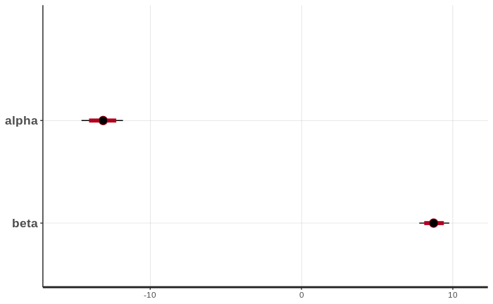

```r
plot(samples)
```

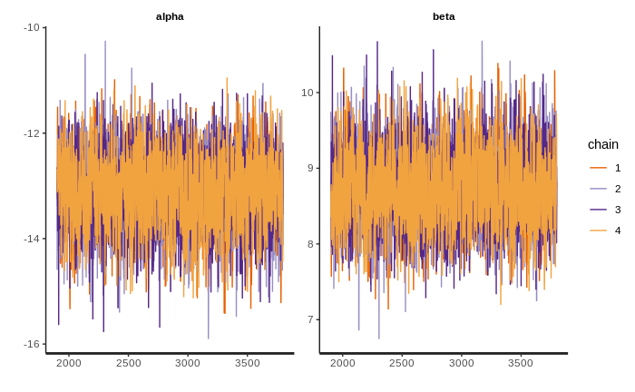

```r
# chain diagnostics
traceplot(samples)
```

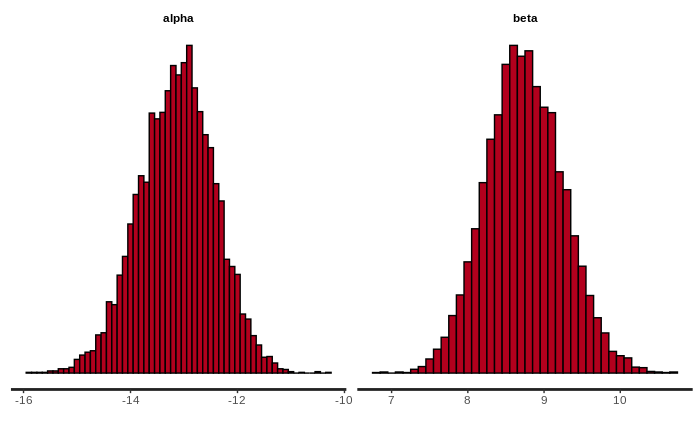

```r
#density histograms
stan_hist(samples, binwidth = 0.1)
```

## 7. Hierarchical Modeling

```r
# Hierarchical Model without NCP
mH = '
data {
  int<lower=1> E;
  vector[E] x;
  int<lower=1> N[E];
  int<lower=0> n[E];
}

parameters {
  vector[E] alpha;
  vector[E] beta;
  real mu_a;
  real mu_b;
  real<lower=0> sigma_a;
  real<lower=0> sigma_b;
}

model {
  mu_a ~ normal(0,20);
  mu_b ~ normal(0,20);
  sigma_a ~ normal(0,5);
  sigma_b ~ normal(0,5);
  alpha ~ normal(mu_a, sigma_a);
  beta ~ normal(mu_b, sigma_b);
  n ~ binomial_logit(N, alpha + beta .* x);
}
'
# Hierarchical Model with NCP

m_H = '
data {
  int<lower=1> E;
  vector[E] x;
  int<lower=1> N[E];
  int<lower=0> n[E];
}

parameters {
  vector[E] a_raw;
  vector[E] b_raw;
  real mu_a;
  real mu_b;
  real<lower=0> sigma_a;
  real<lower=0> sigma_b;
}

transformed parameters {
  vector[E] alpha = mu_a + sigma_a * a_raw;
  vector[E] beta = mu_b + sigma_b * b_raw;
}

model {
  mu_a ~ normal(0,20);
  mu_b ~ normal(0,20);
  sigma_a ~ normal(0,2);
  sigma_b ~ normal(0,2);
  a_raw ~ std_normal();
  b_raw ~ std_normal();
  n ~ binomial_logit(N, alpha + beta .* x);
}
'
```

```r
s_hh = stan(model_code = m_H, data = d, chains = 4, iter = 50000, algorithm = 'HMC')
```

## 8. Hierarchical Resuls

```
ci_level: 0.8 (80% intervals)
outer_level: 0.95 (95% intervals)
```

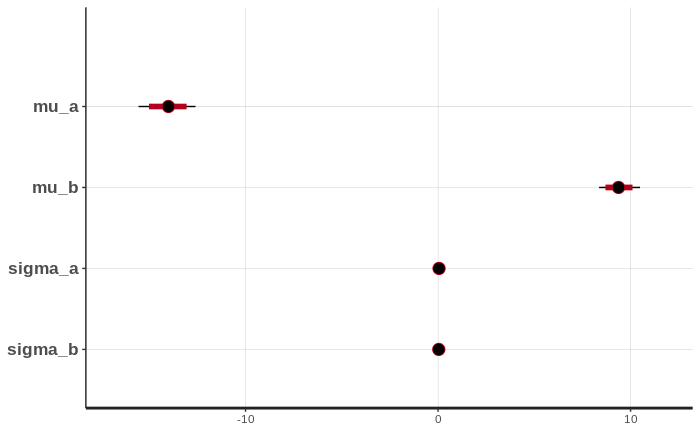

```r
plot(s_hh, pars = c('mu_a', 'mu_b', 'sigma_a', 'sigma_b'))
```

```r
print(s_hh, pars = c('mu_a', 'mu_b', 'sigma_a', 'sigma_b'))
```

```
Inference for Stan model: c6804e8b978a3e25868d36b131c0d591.
4 chains, each with iter=50000; warmup=25000; thin=1;
post-warmup draws per chain=25000, total post-warmup draws=1e+05.

          mean se_mean   sd   2.5%    25%    50%    75%  97.5% n_eff Rhat
mu_a    -14.03    0.01 0.76 -15.56 -14.53 -14.01 -13.51 -12.60  3202    1
mu_b      9.39    0.01 0.54   8.36   9.02   9.38   9.75  10.49  3195    1
sigma_a   0.06    0.00 0.05   0.00   0.02   0.05   0.09   0.17 43070    1
sigma_b   0.04    0.00 0.03   0.00   0.02   0.04   0.06   0.13 40065    1

Samples were drawn using HMC(diag_e) at Sat Aug 29 01:29:02 2020.
For each parameter, n_eff is a crude measure of effective sample size,
and Rhat is the potential scale reduction factor on split chains (at
convergence, Rhat=1).
```

```r
print(sum(get_elapsed_time(s_hh)))
```

```
[1] 280.804
```

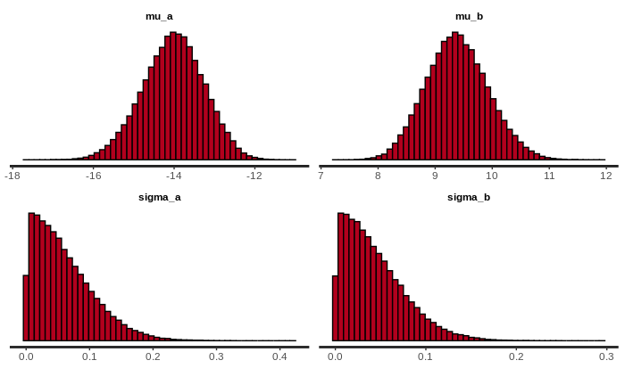

```r
stan_hist(s_hh, pars=c('mu_a', 'mu_b', 'sigma_a', 'sigma_b'), bins=50)
```

## 9. Comparison of Models

```r
p <- read.csv("~/Desktop/MSc Project/survival.csv")
df1 = data.frame(p)

# Experimental Data points
plot(p, pch=16, cex=1.5, col=alpha("#69b3a2",0.6), xlab="Dosage", ylab=expression('P'['survival']), cex.lab=1.3, cex.axis=1.2)

# Hill Model
curve(0.9782/(1+(1.51/x)^13.6140), 0.730, 1.890, add=TRUE, col="orange", lwd = 3)
```

```r
# Hierarchical Model without NCP
curve(exp(-14.09+9.40*x)/(1+exp(-14.09+9.40*x)), 0.730, 1.890, add=TRUE, col="purple", lwd = 3)

# Hierarchical Model with NCP
curve(exp(-14.03+9.39*x)/(1+exp(-14.03+9.39*x)), 0.730, 1.890, add=TRUE, col="red", lwd = 3)
```

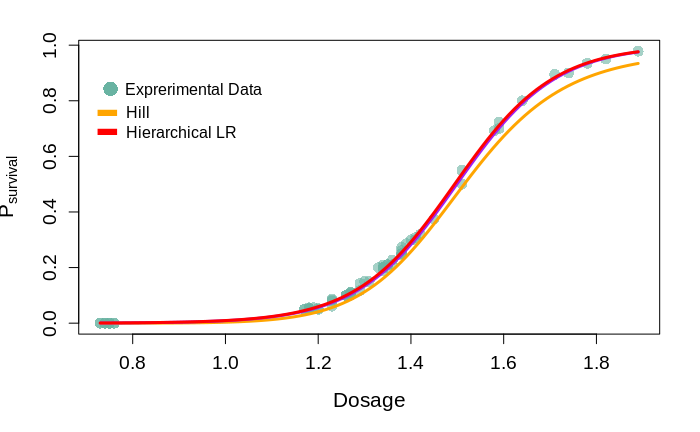

```r
legend("topleft", legend = c('Exprerimental Data'), col = c('#69b3a2'), pch =16, bty = "n", pt.cex = 2, cex = 1,  text.col = "black", horiz = F , inset = c(0.03, 0.1))
legend("topleft", legend = c(' Hill', ' Hierarchical LR'), col = c('orange', 'red'), pch =c('-'), bty = "n", pt.cex = 5, cex = 1,  text.col = "black", horiz = F , inset = c(0.025, 0.18))
```

## 10. Prior and Posterior Densities in Non-Hierarchical Models

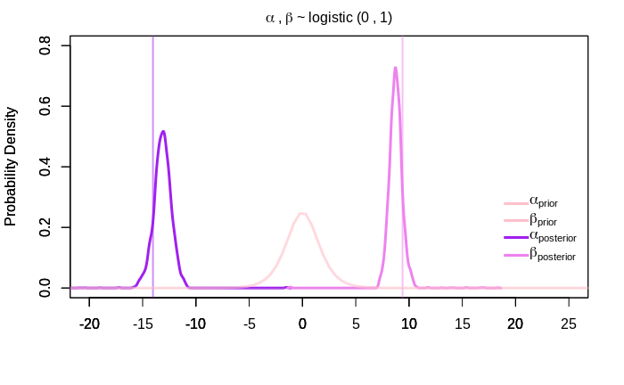

```r
prior_posterior_vis(s5, 'logistic', 0, 1, m = expression(paste(alpha, ' , ', beta, ' ~ logistic (0 , 1)')))
```

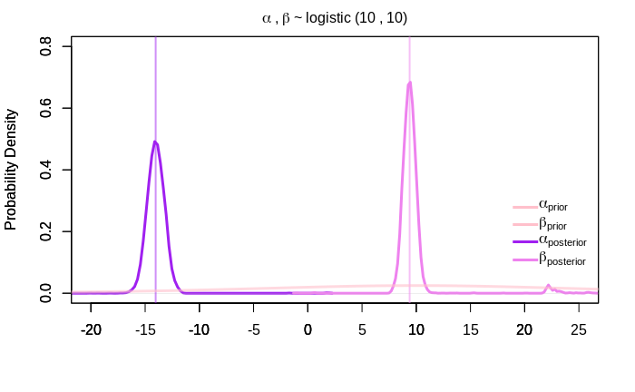

```r
prior_posterior_vis(s7, 'logistic', 10, 10, m = expression(paste(alpha, ' , ', beta, ' ~ logistic (10 , 10)')))
```

[figure not shown]

```r
prior_posterior_vis(s8, 'normal', 0, 20, m = expression(paste(alpha, ' , ', beta, ' ~ normal (0 , 20)')))
```

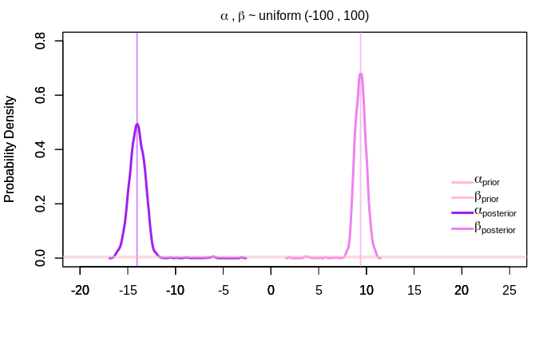

```r
prior_posterior_vis(s13, 'uniform', -100, 100, m = expression(paste(alpha, ' , ', beta, ' ~ uniform (-100 , 100)')))
```

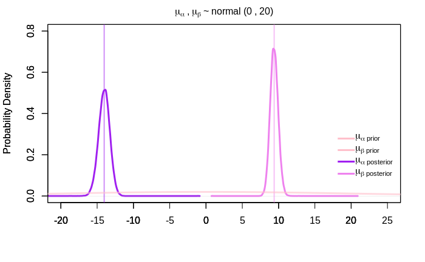

```r
prior_posterior_vis(s_hh, 'normal', 0, 20, a="mu_a", b="mu_b",
                    m = expression(paste(mu[alpha], ' , ', mu[beta], ' ~ normal (0 , 20)')),
                    l = c(expression(mu[alpha][' prior'], mu[beta][' prior'], mu[alpha][' posterior'], mu[beta][' posterior'])))
```

## 8. Comparison with AgenaRisk

```r
# MU

xa <- seq(-20, 0, length=1000)
rstan_mua = dnorm(xa, -14.03, 0.76)
agena_mua = dnorm(xa, -15.555, 0.2548)

xb <- seq(0, 15, length=1000)
rstan_mub = dnorm(xb, 9.39, 0.54)
agena_mub = dnorm(xb, 10.48, 0.18485)

par(mfrow=c(2,2))
plot(xa, agena_mua, type="l", xlim=c(-20, -10), ylim=c(0, 2.5), col="green", lwd = 3, xlab='', main=expression(mu[alpha]), ylab='Probability Density', cex.main=1.5, font.main = 1)
xlabel <- seq(-30, 30, by = 2)
axis(1, at = xlabel, las = 1)
```

```r
par(new=TRUE)
plot(xa, rstan_mua, type='l', xlim=c(-20, -10), ylim=c(0, 2.5), col="#42e0f5", lwd = 3, xlab='', ylab='', main='')
```

```r
legend("topright", legend = c(' Rstan', ' AgenaRisk'), col = c("#42e0f5", "green"), pch = c("____ "), bty = "n", pt.cex = 3, cex = 0.9, text.col = "black", horiz = F , inset = c(0.01, 0.1))
par(new=TRUE)
```

```r
abline(xlim=c(-20, -10), ylim=c(0, 2.5), v=-14.03, col=alpha("#42e0f5", 0.5), lwd=2)
par(new=TRUE)
```

```r
abline(xlim=c(-20, -10), ylim=c(0, 2.5), v=-15.555, col=alpha("green", 0.5), lwd=2)

plot(xb, agena_mub, type="l", xlim=c(5, 15), ylim=c(0, 2.5), col="green", lwd = 3, xlab='', main=expression(mu[beta]), ylab='', cex.main=1.5, font.main = 1)
```

```r
xlabel <- seq(-30, 30, by = 2)
axis(1, at = xlabel, las = 1)
par(new=TRUE)
```

```r
plot(xb, rstan_mub, type='l', xlim=c(5, 15), ylim=c(0, 2.5), col="#42e0f5", lwd = 3, xlab='', ylab='', main='')
par(new=TRUE)
```

```r
abline(xlim=c(5, 15), ylim=c(0, 2.5), v=9.39, col=alpha("#42e0f5", 0.5), lwd=2)
par(new=TRUE)
```

```r
abline(xlim=c(5, 15), ylim=c(0, 2.5), v=10.48, col=alpha("green", 0.5), lwd=2)

# SIGMA

sa <- seq(0, 2, length=1000)
rstan_siga = dnorm(sa, 0.06, 0.05)
agena_siga = dnorm(sa, 0.02, 0.01)

sb <- seq(0, 2, length=1000)
rstan_sigb = dnorm(sb, 0.04, 0.03)
agena_sigb = dnorm(sb, 0.01, 0.01)

plot(sa, agena_siga, type="l", xlim=c(0, 0.4), ylim=c(0, 45), col="green", lwd = 3, xlab='', main=expression(sigma[alpha]), ylab='Probability Density', cex.main=1.5, font.main = 1)
```

```r
xlabel <- seq(-2, 2, by = 0.1)
axis(1, at = xlabel, las = 0.2)
par(new=TRUE)
```

```r
plot(sa, rstan_siga, type='l', xlim=c(0, 0.4), ylim=c(0, 45), col="#42e0f5", lwd = 3, xlab='', ylab='', main='')
par(new=TRUE)
```

```r
abline(xlim=c(0, 0.4), ylim=c(0, 20), v=0.06, col=alpha("#42e0f5", 0.5), lwd=2)
par(new=TRUE)
```

```r
abline(xlim=c(0, 0.4), ylim=c(0, 20), v=0.02, col=alpha("green", 0.5), lwd=2)

plot(sb, agena_sigb, type="l", xlim=c(0, 0.4), ylim=c(0, 45), col="green", lwd = 3, xlab='', main=expression(sigma[beta]), ylab='', cex.main=1.5, font.main = 1)
```

```r
xlabel <- seq(-2, 2, by = 0.2)
axis(1, at = xlabel, las = 0.2)
par(new=TRUE)
```

```r
plot(sb, rstan_sigb, type='l', xlim=c(0, 0.4), ylim=c(0, 45), col="#42e0f5", lwd = 3, xlab='', ylab='', main='')
par(new=TRUE)
```

```r
abline(xlim=c(0, 0.4), ylim=c(0, 20), v=0.04, col=alpha("#42e0f5", 0.5), lwd=2)
par(new=TRUE)
```

[figure not shown]

```r
abline(xlim=c(0, 0.4), ylim=c(0, 20), v=0.01, col=alpha("green", 0.5), lwd=2)
```